# Predicting Redistribution Preferences

Matias Strehl

December, 2022

```r
# Load packages
library(tidyverse)
library(janitor)
library(dplyr)
library(lubridate)
library(magrittr)
library(ggplot2)
library(kableExtra)
library(modelsummary)
library(gt)
library(haven)
library(fixest)
library(tidymodels)
library(ISLR)
library(ISLR2)
library(tidyverse)
library(glmnet)
library(discrim)
library(corrplot)
library(klaR)
library(patchwork)
library(bookdown)
tidymodels_prefer()

library(rpart.plot)
library(vip)
library(randomForest)
library(xgboost)

devtools::install_github("haozhu233/kableExtra")

set.seed(17)
```

# 1 Introduction

Economists have made great efforts to understand what shape people redistribution preferences. In this paper, I will apply a Machine Learning approach to predict redistribution preferences of workers in Uruguay. To do that, I exploit novel survey data on workers’ social and economic preferences, combined with individual tax records that allow to accurately obtain measures of redistribution preferences, behavioral parameters and beliefs that the literature point as key determinants of redistribution preferences, sociodemographic characteristics, and other characteristics of workers’ jobs.

To do that, I will perform two main analysis. First, I use validation set, cross-validation and regularization to choose the best-performing model between a LOGISTIC, a Linear Discrimant Analysis, and a Quadratic Discriminant Analysis. Second, I use tree-based approach. Particularly, I perform a pruned single tree, a random forest, and a boosted tree, and use cross-validation to choose the best-performing model. Next, I compare the performance of all the models in the folds in order to choose the best-performing model. Finally, I fit the best model to the testing set and assess its predicting performance.

# 2 Data

## 2.1 Description of the data

This paper use a combination of survey data and tax records that can be linked at the individual level.

On the one hand, survey data comes from the Encuesta de Preferencias sociales y Economicas (EPSE), which is a survey carried out in Uruguay in 2019 with data about social and economic preferences of workers. This data set allows us to have accurate measures of redistribution preferences – the outcome of interest of this paper–, behavioral parameters, other beliefs and opinions, and some sociodemographic characteristics that will be used as predictors.

On the other hand, administrative tax records have rich individual-level data about wages, capital income, job characteristics, taxes, and some sociodemographic characteristics, for the 2009-2016 period.

I leverage the possibility of linking these two data sets at the individual level, which constitutes a unique empirical setting, to try to predict redistribution preferences of workers in Uruguay.

I now briefly describe the main variables I use in the paper. First, the outcome of interest is *redistribution preferences*. To measure this outcome I use a categorical variable that takes on 4 values according to the answer to the following question: *How much do you agree with the following statement?* “The government should take actions to reduce inequality between rich and poor people”, where the possible answers are “Totally agree”, “Partially agree”, “Partially disagree” and “Totally disagree”. For simplicity of the analysis, I create a binary variable that takes the value 1 if the individual is totally agree with the statement, and 0 otherwise. Hence, I measure the outcome of interest with this binary variable that indicates whether the individual fully supports redistribution or not.

The second group consists of behavioral parameters captured by laboratory games that individuals perform in the survey. These variables are risk aversion (*risk_aversion*), impatience (*impatience*), altruism (*altruism*), inequality aversion (*inequality_aversion*), trust in others (*trust_game*), tolerance for inequality (*ineq_tolerance*), and reciprocity/rationalism (*ultimatum*).

Finally, the last group of predictors consists of beliefs and opinions that come from survey questions. These variables are meritocratic beliefs (*meritocratic_pref*), perceived mobility (*perceived_mobility*), perceived inequality (*perceived_inequality*), trust in government (*trust_gov*), perceived government efficiency (*gov_efficiency*), and political ideology (*political_ideology*).

Note: for simplicity, all numeric predictors are standarized so they have a mean of zero and a standard deviation of one when working with models. Besides, all predictors that are not dummy variables are treated as numerical.

## 2.2 Data Cleaning

Before starting the analysis, it is worth to perform some data cleaning. Regarding missing values, the survey measures do not suffer from this problem, but it is worth to check whether administrative data variables have missing values or not. We observe that neither *total_income_2016* nor *i_capital* – the two variables we will use from administrative data – have missing values. Then, we select only the variables we will use to predict our outcome of interest, and rename some of them in order to have more intuitive names for the analysis. Finally, we change the binary variables to factors.

```r
# Load data
raw_data <- read_dta("Wide_2009_2016_ready_survey.dta")

# Check number of missing values of variables from administrative data
sum(is.na(raw_data$total_income_2016))
```

```
## [1] 0
```

```r
sum(is.na(raw_data$i_capital))
```

```
## [1] 0
```

```r
# Keep only the variables I will use for prediction and change some variable names
data <- raw_data %>%
  select(pref_redistribution, total_income_2016, age, gender, education, i_capital,
         risk_aversion, impatience_share, dictator_reg, inequality_aversion,
         trust_game, merit_pref_reg, ultimatum,
         meritocratic_pref, perc_mobility_reg,
         perceived_inequality, trust_gov, gov_efficiency, political_ideology) %>%
  mutate(gender = ifelse(gender==2,1,0)) %>%
  rename(impatience = impatience_share,
         altruism = dictator_reg,
         ineq_tolerance = merit_pref_reg,
         perceived_mobility = perc_mobility_reg)  # Change column names to a more intuitive name

# Create the outcome of interest
data <- data %>%
  mutate(pref_red_new = ifelse(pref_redistribution == 4, "favor", "against" )) %>%
  select(-pref_redistribution) %>%
  rename(pref_redistribution = pref_red_new)

# Change every discrete variable to factors
data_character <- data %>%
  select(-total_income_2016, -age) %>% # create a vector with every discrete variable for histograms
  colnames()

# For histograms we factor all discrete variables
data_histograms <- data %>%
  mutate(across(data_character, ~ as.factor(.))) # change them to factors

data_histograms$pref_redistribution <- factor(data$pref_redistribution, levels = c("favor", "against")) # reorder outcome of interest

# Change some variables to factors in the main data
factors_vector <- data %>%
  select(pref_redistribution, gender, i_capital, inequality_aversion, trust_game, ultimatum) %>%
  colnames()  # create auxiliar vector with variables to change to factors

data <- data %>%
  mutate(across(factors_vector, ~ as.factor(.) )) # change some variables to factor

data$pref_redistribution <- factor(data$pref_redistribution, levels = c("favor", "against")) # reorder outcome of interest

#levels(data$pref_redistribution)
```

## 2.3 Data Visualization

Figure 2.1 shows the distribution of redistribution preferences, the outcome of interest of the paper. We can see that 40% of the sample supports higher redistribution levels, while 60% do not.

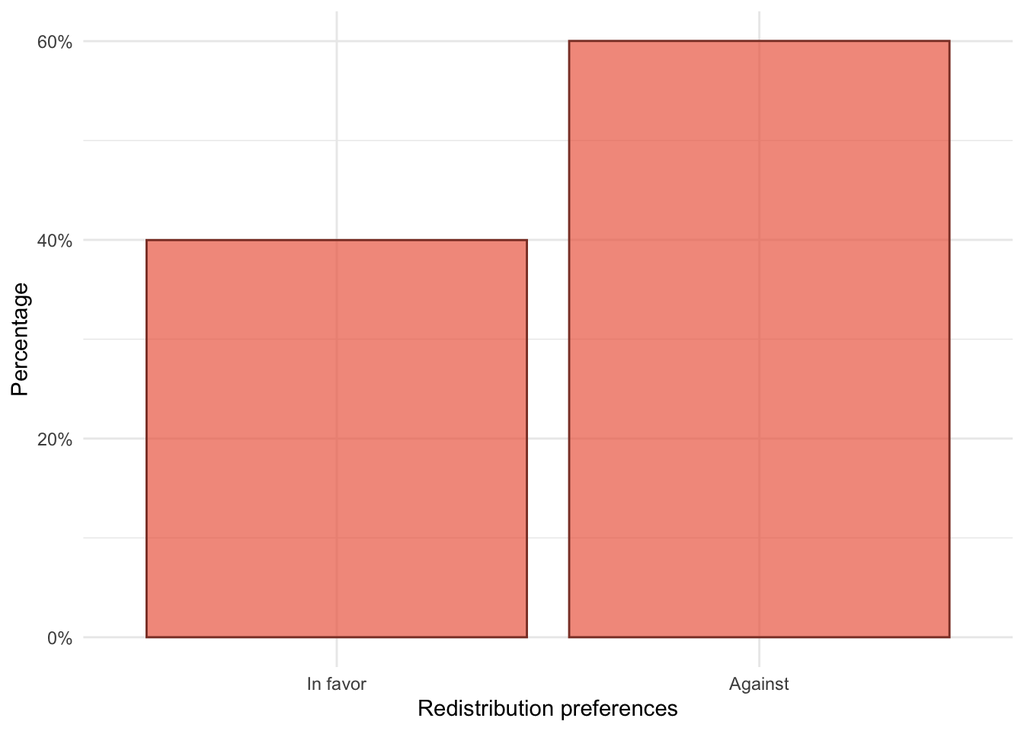

Figure 2.1: Distribution of redistribution preferences

```r
# Histogram of redistribution preferences
data %>%
ggplot(aes(x=pref_redistribution, y = (..count..)/sum(..count..) )) +
  geom_bar(color = "coral4", fill = "coral2", alpha = 0.7) +
  scale_y_continuous(labels = percent) +
  scale_x_discrete(labels = c("In favor", "Against")) +
  labs(x = "Redistribution preferences",
       y = "Percentage") +
  theme_minimal()
```

Next, we present the distribution of the predictors. First, we present the distribution of sociodemographic variables. Figure 2.2 and Table 2.1 show the distribution of these variables. We can see that income is – as expected – right skewed since there are several high-income outliers, and that the annual income mean is close to 1 million Uruguayan pesos (the median is almost 750,000 Uruguayan pesos). Notice that the sample is representative of the richest half of the Uruguayan workforce. Also, since this is a sample of workers, most participants are over 18 years old, where the average age is 41 years old. Women and highly educated people are over-represented in the sample, as we can observe that 60% of the sample are women and the average education level is higher than 5, which means that, on average, the sample is college educated. Finally, only 9% of the sample have capital income. This is expected, since capital income is highly concentrated on a rich and small portion of the population.

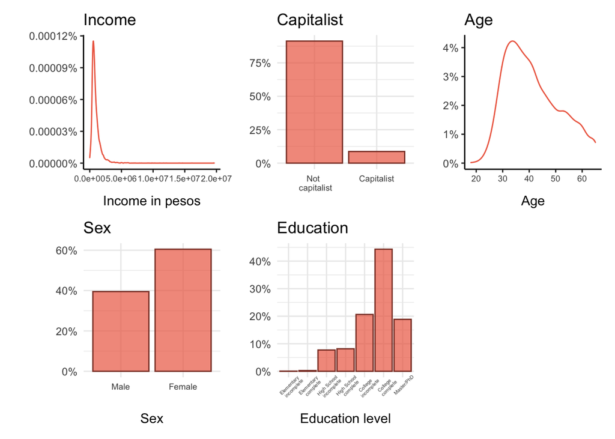

Figure 2.2: Distribution of sociodemographic predictors

```r
# Sociodemographic plots
inc_boxplot <- data_histograms %>%
  ggplot(aes(x = total_income_2016)) +
  geom_boxplot(fill = "coral2", color = "coral4", alpha = 0.7) +
  labs(
    title = "Distribution of Income",
    x = "Number of cylinders",
    y = "Income in pesos" ) +
  theme_classic() +
  theme(axis.text.x = element_text(size=7) )


inc_density <- data_histograms %>%
  filter(total_income_2016<30000000) %>%
  ggplot(aes(x = total_income_2016)) +
  geom_density(color = "coral2", alpha = 0.7) +
  scale_y_continuous(labels = percent) +
  labs(
    title = "Income",
    x = "Income in pesos",
    y = "" ) +
  theme_classic() +
  theme(axis.text.x = element_text(size=7) )


age_density <- data_histograms %>%
  ggplot(aes(x = age)) +
  geom_density(color = "coral2", alpha = 0.7) +
  scale_y_continuous(labels = percent) +
  labs(
    title = "Age",
    x = "Age",
    y = "") +
  theme_classic() +
  theme(axis.text.x = element_text(size=7) )

sex_hist <- data_histograms %>%
  ggplot(aes(x=gender, y = (..count..)/sum(..count..) )) +
  geom_bar(color = "coral4", fill = "coral2", alpha = 0.7) +
  scale_y_continuous(labels = percent) +
  scale_x_discrete(labels = c("Male", "Female")) +
  labs(title = "Sex",
       x = "Sex",
       y = "") +
  theme_minimal() +
  theme(axis.text.x = element_text(size=7) )


edu_hist <- data_histograms %>%
  ggplot(aes(x=education, y = (..count..)/sum(..count..) )) +
  geom_bar(color = "coral4", fill = "coral2", alpha = 0.7) +
  scale_y_continuous(labels = percent) +
  scale_x_discrete(labels = c("Elementary \n incomplete", "Elementary \n complete",
                              "High School \n incomplete", "High School \n complete",
                              "College \n incomplete", "College \n complete",
                              "Master/PhD")) +
    labs(title = "Education",
       x = "Education level",
       y = "") +
  theme_minimal() +
  theme(axis.text.x = element_text(size=4, angle=45) )

capital_hist <- data_histograms %>%
  ggplot(aes(x = i_capital, y = (..count..)/sum(..count..) )) +
  geom_bar(color = "coral4", fill = "coral2", alpha = 0.7) +
  scale_y_continuous(labels = percent) +
  scale_x_discrete(labels = c("Not \n capitalist", "Capitalist")) +
  labs(title = "Capitalist",
       x = "",
       y = "") +
  theme_minimal() +
  theme(axis.text.x = element_text(size=7) )


inc_density + capital_hist + age_density + sex_hist + edu_hist
```

```r
variable_names <- data %>%
  colnames()

data_numeric <- data %>%
  mutate(across(variable_names, ~ as.numeric(.) )) %>%
  mutate(i_capital = ifelse(i_capital==2, 100, 0)) %>%
  mutate(gender = ifelse(gender==2, 100, 0)) %>%
  select(`Income` = total_income_2016,
         `Capitalists (%)` = i_capital,
         `Age` = age, `Female (%)` = gender,
         `Education level` = education)


# Table with summary statistics
table_1 <- datasummary(`Income` + `Capitalists (%)` +
                        `Age` + `Female (%)` + `Education level`
                        ~ (Mean + SD),
                       data = data_numeric,
                       fmt = 1,
                       output = "data.frame")

kbl(table_1,
    caption = "<center>Summary statistics of sociodemographic predictors",
    booktabs = TRUE,
    escape = FALSE,
    align = "lcc") %>%
  kable_classic(full_width = T)
```

Table 2.1: Summary statistics of sociodemographic predictors

|  | Mean | SD |
| --- | --- | --- |
| Income | 956132.4 | 827217.3 |
| Capitalists (%) | 8.7 | 28.2 |
| Age | 41.4 | 10.2 |
| Female (%) | 60.5 | 48.9 |
| Education level | 5.6 | 1.1 |

Figure 2.3 presents the distribution of behavioral parameters. These parameters are all measured by variables that come from laboratory games of the survey data. The figure shows that, on average, the sample is quite risk averse, impatience levels are evenly-distributed across the sample, the majority has high levels of altruism, the sample is highly inequality averse, half of the participants decide to trust in others in the trust game, tolerance for inequality is concentrated at the medium level, and, finally, most of the sample accept a low offer in the ultimatum game.

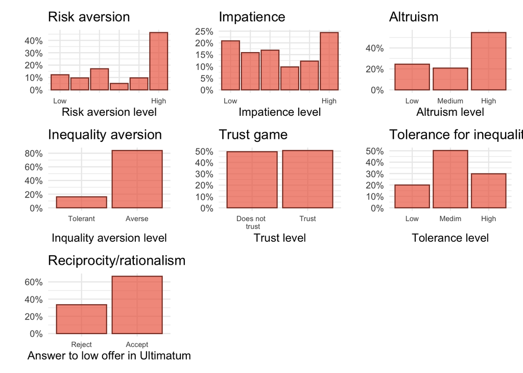

Figure 2.3: Distribution of behavioral predictors

```r
# Behavioral parameters plots

# Hist
risk_hist <- data_histograms %>%
  ggplot(aes(x=risk_aversion, y = (..count..)/sum(..count..) )) +
  geom_bar(color = "coral4", fill = "coral2", alpha = 0.7) +
  scale_y_continuous(labels = percent) +
  scale_x_discrete(labels = c("Low", "", "", "", "", "High")) +
  labs(title = "Risk aversion",
       x = "Risk aversion level",
       y = "") +
  theme_minimal() +
  theme(axis.text.x = element_text(size=7))

# Hist
impatience_hist <- data_histograms %>%
  ggplot(aes(x=impatience, y = (..count..)/sum(..count..) )) +
  geom_bar(color = "coral4", fill = "coral2", alpha = 0.7) +
  scale_y_continuous(labels = percent) +
  scale_x_discrete(labels = c("Low", "", "", "", "", "High")) +
  labs(title = "Impatience",
       x = "Impatience level",
       y = "") +
  theme_minimal() +
  theme(axis.text.x = element_text(size=7) )

# Hist
altruism_hist <- data_histograms %>%
  ggplot(aes(x=altruism, y = (..count..)/sum(..count..) )) +
  geom_bar(color = "coral4", fill = "coral2", alpha = 0.7) +
  scale_y_continuous(labels = percent) +
  scale_x_discrete(labels = c("Low", "Medium", "High")) +
  labs(title = "Altruism",
       x = "Altruism level",
       y = "") +
  theme_minimal() +
  theme(axis.text.x = element_text(size=7) )

# Hist
ineq_aversion_hist <- data_histograms %>%
  ggplot(aes(x=inequality_aversion, y = (..count..)/sum(..count..) )) +
  geom_bar(color = "coral4", fill = "coral2", alpha = 0.7) +
  scale_y_continuous(labels = percent) +
  scale_x_discrete(labels = c("Tolerant", "Averse")) +
  labs(title = "Inequality aversion",
       x = "Inquality aversion level",
       y = "") +
  theme_minimal() +
  theme(axis.text.x = element_text(size=7))

# Hist
trust_hist <- data_histograms %>%
  ggplot(aes(x=trust_game, y = (..count..)/sum(..count..) )) +
  geom_bar(color = "coral4", fill = "coral2", alpha = 0.7) +
  scale_y_continuous(labels = percent) +
  scale_x_discrete(labels = c("Does not \n trust", "Trust")) +
  labs(title = "Trust game",
       x = "Trust level",
       y = "") +
  theme_minimal() +
  theme(axis.text.x = element_text(size=7) )

# Hist
ineq_tolerance_hist <- data_histograms %>%
  ggplot(aes(x=ineq_tolerance, y = (..count..)/sum(..count..) )) +
  geom_bar(color = "coral4", fill = "coral2", alpha = 0.7) +
  scale_y_continuous(labels = percent) +
  scale_x_discrete(labels = c("Low", "Medim", "High")) +
  labs(title = "Tolerance for inequality",
       x = "Tolerance level",
       y = "") +
  theme_minimal() +
  theme(axis.text.x = element_text(size=7) )

# Hist
ultimatum_hist <- data_histograms %>%
  ggplot(aes(x=ultimatum, y = (..count..)/sum(..count..) )) +
  geom_bar(color = "coral4", fill = "coral2", alpha = 0.7) +
  scale_y_continuous(labels = percent) +
  scale_x_discrete(labels = c("Reject", "Accept")) +
  labs(title = "Reciprocity/rationalism",
       x = "Answer to low offer in Ultimatum",
       y = "") +
  theme_minimal() +
  theme(axis.text.x = element_text(size=7) )

# Plot behavioral parameters
risk_hist + impatience_hist + altruism_hist + ineq_aversion_hist +
  trust_hist + ineq_tolerance_hist + ultimatum_hist
```

Finally, Figure 2.4 shows the distribution of the last group of predictors: beliefs and opinions. We observe that 60% of the participants have weak meritocratic beliefs, more than 40% perceive that the mobility level is low, and more than 80% believe that inequality levels are too high. Besides this, approximately 80% of the participants have either medium or low levels of trust in government, while almost no one thinks that the government is highly efficient. Lastly, 49.4% of the participants place themselves on the left wing of the left-right political spectrum, 22.7% are on the right wing, and the remaining 27.9% place themselves at the center.

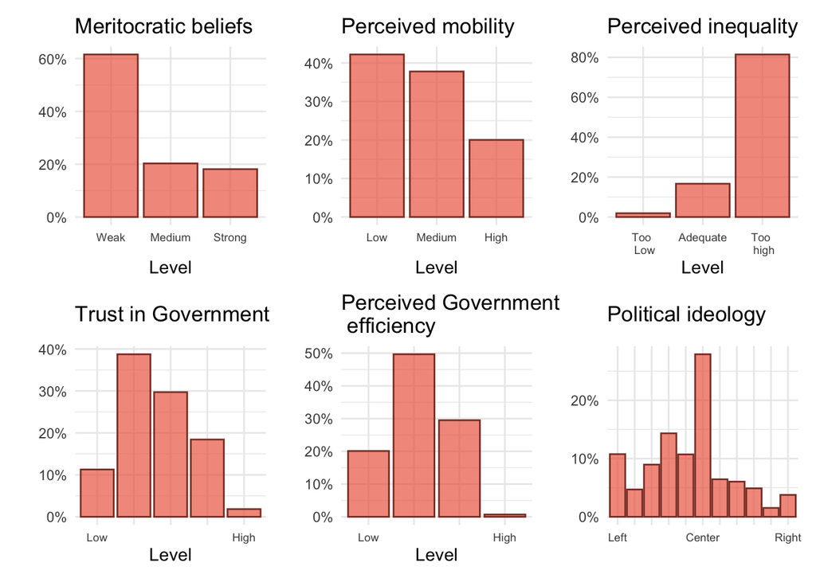

Figure 2.4: Distribution of beliefs and opinions

```r
# Plot beliefs and opinions
meritocratic_hist <- data_histograms %>%
  ggplot(aes(x = meritocratic_pref, y = (..count..)/sum(..count..) )) +
  geom_bar(color = "coral4", fill = "coral2", alpha = 0.7) +
  scale_y_continuous(labels = percent) +
  scale_x_discrete(labels = c("Weak", "Medium", "Strong")) +
  labs(title = "Meritocratic beliefs",
       x = "Level",
       y = "") +
  theme_minimal() +
  theme(axis.text.x = element_text(size=7) )

mobility_hist <- data_histograms %>%
  ggplot(aes(x = perceived_mobility, y = (..count..)/sum(..count..) )) +
  geom_bar(color = "coral4", fill = "coral2", alpha = 0.7) +
  scale_y_continuous(labels = percent) +
  scale_x_discrete(labels = c("Low", "Medium", "High")) +
  labs(title = "Perceived mobility",
       x = "Level",
       y = "") +
  theme_minimal() +
  theme(axis.text.x = element_text(size=7) )

perc_ineq_hist <- data_histograms %>%
  ggplot(aes(x = perceived_inequality, y = (..count..)/sum(..count..) )) +
  geom_bar(color = "coral4", fill = "coral2", alpha = 0.7) +
  scale_y_continuous(labels = percent) +
  scale_x_discrete(labels = c("Too \n Low", "Adequate", "Too \n high")) +
  labs(title = "Perceived inequality",
       x = "Level",
       y = "") +
  theme_minimal() +
  theme(axis.text.x = element_text(size=7) )

trust_gov_hist <- data_histograms %>%
  ggplot(aes(x = trust_gov, y = (..count..)/sum(..count..) )) +
  geom_bar(color = "coral4", fill = "coral2", alpha = 0.7) +
  scale_y_continuous(labels = percent) +
  scale_x_discrete(labels = c("Low", "", "", "", "High")) +
  labs(title = "Trust in Government",
       x = "Level",
       y = "") +
  theme_minimal() +
  theme(axis.text.x = element_text(size=7) )

gov_efficiency_hist <- data_histograms %>%
  ggplot(aes(x = gov_efficiency, y = (..count..)/sum(..count..) )) +
  geom_bar(color = "coral4", fill = "coral2", alpha = 0.7) +
  scale_y_continuous(labels = percent) +
  scale_x_discrete(labels = c("Low", "", "", "High")) +
  labs(title = "Perceived Government \n efficiency",
       x = "Level",
       y = "") +
  theme_minimal() +
  theme(axis.text.x = element_text(size=7) )

ideology_hist <- data_histograms %>%
  ggplot(aes(x = political_ideology, y = (..count..)/sum(..count..) )) +
  geom_bar(color = "coral4", fill = "coral2", alpha = 0.7) +
  scale_y_continuous(labels = percent) +
  scale_x_discrete(labels = c("Left", "", "", "", "", "Center", "",
                              "", "", "", "Right")) +
  labs(title = "Political ideology",
       x = "",
       y = "") +
  theme_minimal() +
  theme(axis.text.x = element_text(size=7) )

# Plot beliefs and opinions
meritocratic_hist + mobility_hist + perc_ineq_hist + trust_gov_hist +
  gov_efficiency_hist + ideology_hist
```

For prediction purposes, it is relevant to understand the potential correlations of all these variables. Figure 2.5 presents a correlation matrix for all the variables (both predictors and the outcome of interest).

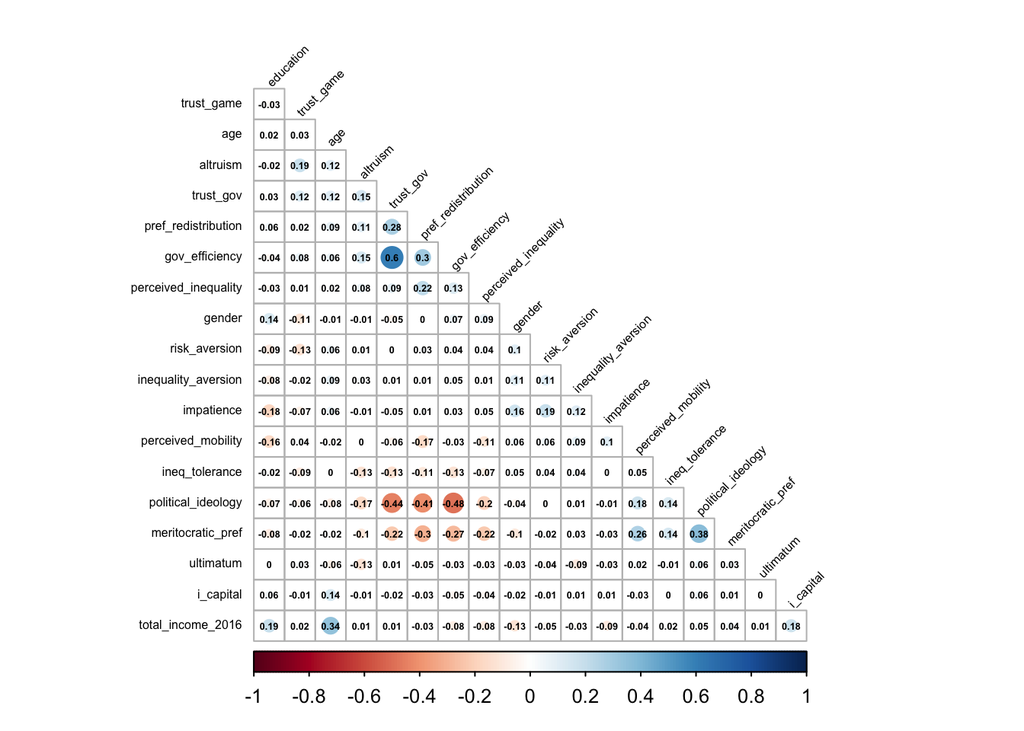

Figure 2.5: Correlation Matrix

```r
# Create a correlation matrix between all variables
data_predictors <- data %>%
  select(-pref_redistribution)

auxiliar <- data %>%
  mutate(aux = ifelse(pref_redistribution=="favor", 1, 0)) %>%
  select(aux) %>%
  rename(pref_redistribution = aux)

# All variables to numeric
corr_matrix <- data.frame(lapply(data_predictors, function(x) as.numeric(as.character(x))))
corr_matrix <- bind_cols(corr_matrix, auxiliar)

# Correlation matrix of all predictors and pref_redistribution
corrplot(cor(corr_matrix), method = 'circle', order = "AOE", type = "lower",
         diag = FALSE, tl.srt = 45, tl.col = "black", tl.cex = 0.5,
        addCoef.col = 'black',  number.cex = 0.4)
```

Figure 2.5 shows that, overall, these variables are not highly correlated. Regarding the outcome of interest, redistribution preferences, we observe that supporting higher redistribution levels is positively correlated with having positive opinions of the government (both trust and efficiency perception), with the perceived level of inequality, and with higher levels of altruism. On the other hand, supporting more redistribution is negatively correlated with more right-win political ideology positions, higher meritocratic preferences, higher inequality tolerance, and higher perceived levels of income mobility. Overall, all these correlations have the expected sign, according to the theory and past evidence.

Between the predictors, those that are highly positively correlated are trust in government and government efficiency, income and age, income and education level, right-win political ideology and meritocratic preferences, perceived mobility and meritocratic preferences, perceived mobility and right-win political ideology. On the other hand, the predictors that are highly negatively correlated are right-win political ideology and government opinions (trust and perceived efficiency) and perceived inequality, meritocratic preferences and government opinions (both trust and perceived efficiency) and perceived inequality. Again, these correlations between predictors have the expected sign.

# 3 Choosing the best model

In this section, I split the data into a training and a testing set, what will allow to work with Machine Learning techniques throughout the rest of the paper. In order to balance the distribution of the outcome of interest, we stratify by redistribution preferences when splitting the data. Also, we choose the proportions so the training set contains 70% of the observations and the testing set contains the remaining 30%.

```r
# Split the data
data_split <- initial_split(data, prop = 0.7, strata = "pref_redistribution" )
data_train <- training(data_split)
data_test <- testing(data_split)

# Check dimensions of train and test sets
dim(data_train)
```

```
## [1] 5196   19
```

```r
dim(data_test)
```

```
## [1] 2228   19
```

We observe that the training set contains 5196 observations and the testing set 2228 observations, which correspond to 70% and 30% of the total sample, respectively, as expected.

## 3.1 Validation set approach

In this section, I will asses the performance of three different models to predict redistribution preferences: logistic regression (LOGISTIC), linear discriminant analysis (LDA) and quadratic discriminant analysis (QDA), using the validation set approach.

To do that, before doing any analysis, we first create a recipe and set the regression model and workflow for each of the three specified models.

```r
# Create a recipe
my_recipe <- recipe(pref_redistribution ~
                      total_income_2016 + age + gender + education +
         risk_aversion + impatience + altruism + inequality_aversion + trust_game +
         ineq_tolerance + ultimatum + meritocratic_pref + perceived_mobility +
         perceived_inequality + trust_gov + gov_efficiency + political_ideology,
         data = data_train) %>%
  step_novel(all_nominal_predictors()) %>%
  step_dummy(all_nominal_predictors()) %>%
  step_zv(all_predictors()) %>%
  step_normalize(all_predictors())

# Logit model
logit_model <- logistic_reg() %>%
  set_engine("glm") %>%
  set_mode("classification")

# Logit workflow
logit_workflow <- workflow() %>%
  add_model(logit_model) %>%
  add_recipe(my_recipe)

# LDA model
lda_model <- discrim_linear() %>%
  set_mode("classification") %>%
  set_engine("MASS")

# LDA workflow
lda_workflow <- workflow() %>%
  add_model(lda_model) %>%
  add_recipe(my_recipe)

# QDA model
qda_model <- discrim_quad()  %>%
  set_mode("classification") %>%
  set_engine("MASS")

# QDA workflow
qda_workflow <- workflow() %>%
  add_model(qda_model) %>%
  add_recipe(my_recipe)
```

We can, now, fit these models to the entire training set and asses their performance. This is known as the validation set approach. Even though we know that a much better way of choosing the best model is to use cross validation and/or regularization, this is still a good exercise so we can appreciate the differences.

```r
# Fit the 3 models to the training set
logit_fit <- fit(logit_workflow, data_train)
lda_fit <- fit(lda_workflow, data_train)
qda_fit <- fit(qda_workflow, data_train)

# Predict redistribution preferences
logit_pred <- predict(logit_fit, new_data = data_train, type = "prob")
lda_pred <- predict(lda_fit, new_data = data_train, type = "prob")
qda_pred <- predict(qda_fit, new_data = data_train, type = "prob")

# Measure accuracy of the models
logit_acc <- augment(logit_fit, new_data = data_train) %>%
  accuracy(truth = pref_redistribution, estimate = .pred_class)

lda_acc <- augment(lda_fit, new_data = data_train) %>%
  accuracy(truth = pref_redistribution, estimate = .pred_class)

qda_acc <- augment(qda_fit, new_data = data_train) %>%
  accuracy(truth = pref_redistribution, estimate = .pred_class)

# Construct a table with accuracy of the models
name_models <- c("Logistic", "LDA", "QDA")
acc_validation <- c(logit_acc$.estimate, lda_acc$.estimate, qda_acc$.estimate) %>%
  as_tibble() %>%
  rename("Accuracy" = value) %>%
  mutate("Model" = name_models) %>%
  mutate_if(is.numeric, format, digits = 3)

# Change order of columns and change
acc_validation <- acc_validation[, c("Model", "Accuracy")]


# Nice Table of the assessment of the models
kbl(acc_validation,
    caption = "<center> Accuracy of the models",
    booktabs = TRUE,
    escape = FALSE,
    align = "lcc") %>%
  kable_classic(full_width = F)
```

Table 3.1: Accuracy of the models

| Model | Accuracy |
| --- | --- |
| Logistic | 0.738 |
| LDA | 0.739 |
| QDA | 0.692 |

Table 3.1 shows the accuracy prediction level of the three models in the training set. We can see that the LOGISTIC model and the LDA achieve the highest level of accuracy, based on the validation approach. This means that if we have to choose the best-performing model based on the validation approach, the LOGISTIC model or the LDA are the ones that do the best job in terms of accuracy, predicting the right category of redistribution preferences 73.8% and 73.9% of the time, respectively.

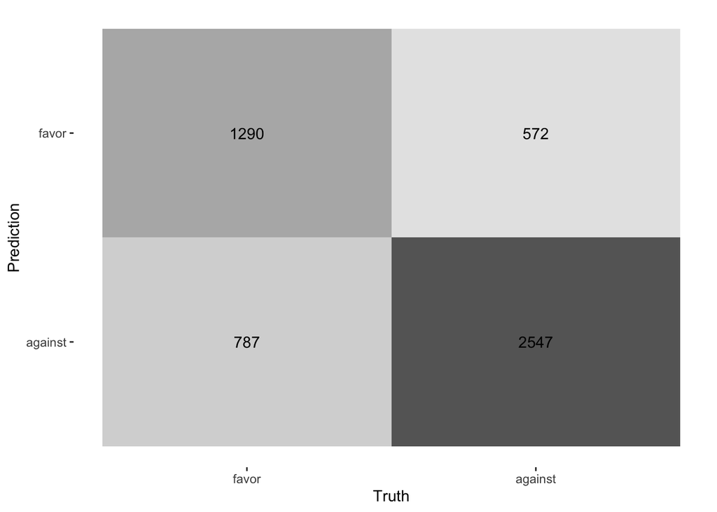

Figure 3.1: Confusion matrix of logistic model

```r
# Confusion matrix of selected model
augment(logit_fit, new_data = data_train) %>%
  conf_mat(truth = pref_redistribution, estimate = .pred_class) %>%
  autoplot(type = "heatmap")
```

By plotting the confusion matrix of the LOGISTIC model in Figure 3.1, we observe that from those that are against more redistribution (3119), this model correctly predicts 81.7% of them (2547), while from those that are in favor of more redistribution (2077), the logit model correctly predicts 62.1% of them (1290). Overall, the model does a better job in predicting those that are against redistribution than those that are in favor of it.

## 3.2 K-fold Cross-validation

Now, I can collect metrics for each model in order to asses their performance.

```r
# Collect metrics: mean and standard errors
logit_metrics <- collect_metrics(logit_res)
lda_metrics <- collect_metrics(lda_res)
qda_metrics <- collect_metrics(qda_res)

#logit_metrics
#lda_metrics
#qda_metrics

# Construct a table with metrics of the model
name_models <- c("Logistic", "LDA", "QDA") %>%
               as_tibble() %>%
              rename("Model" = value)

acc_res <- c(logit_metrics$mean[1], lda_metrics$mean[1],
                    qda_metrics$mean[1]) %>%
           as_tibble() %>%
           rename("Accuracy" = value) %>%
           mutate_if(is.numeric, format, digits = 3)

roc_res <- c(logit_metrics$mean[2], lda_metrics$mean[2],
                    qda_metrics$mean[2]) %>%
          as_tibble() %>%
          rename("ROC-AUC" = value) %>%
          mutate_if(is.numeric, format, digits = 3)

res_table <- bind_cols(name_models, acc_res, roc_res)

# Nice Table of the assessment of the models
kbl(res_table,
    caption = "<center> Mean Accuracy and ROC-AUC of the models in the folds",
    booktabs = TRUE,
    escape = FALSE,
    align = "lcc") %>%
  kable_classic(full_width = F)
```

Table 3.2: Mean Accuracy and ROC-AUC of the models in the folds

| Model | Accuracy | ROC-AUC |
| --- | --- | --- |
| Logistic | 0.733 | 0.783 |
| LDA | 0.735 | 0.782 |
| QDA | 0.680 | 0.768 |

Based on the table, we observe that the best-performing models in terms of average accuracy and ROC-AUC are, again, the LOGISTIC and LDA models. Since the accuracy of the LDA model is slightly greater than LOGISTIC’s accuracy, but the opposite happens regarding ROC-AUC, I conclude that both the LOGISTIC and LDA model are the best-performing models based on to the cross-validation approach.

## 3.3 Regularization

In this section, I take the LOGISTIC model and use hyperparameter tuning in order to find the model that performs the best through regularization. To do that, I use grid search looking only at evenly spaced parameter values. In particular, I create a regular grid for penalty and mixture with 10 levels each; mixture ranges from 0 to 1, and I let penalty range from -5 to 5. When fitting these models to the folded data, we will be fitting 100 models per fold, that is, we will be fitting a total of 500 models.

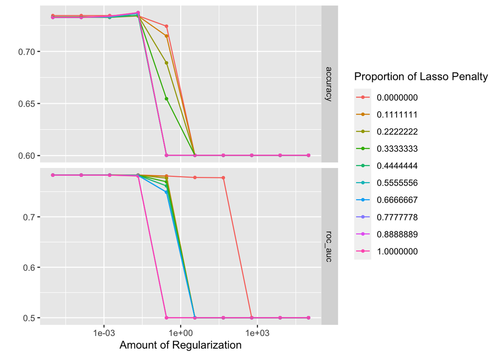

Figure 3.2: Regularization and model performance

```r
# Set model
elastic_net_spec <- logistic_reg(penalty = tune(),
                                 mixture = tune()) %>%
                    set_mode("classification") %>%
                    set_engine("glmnet")
# Set workflow
en_wkflow <- workflow() %>%
             add_recipe(my_recipe) %>%
             add_model(elastic_net_spec)

# Grid
en_grid <- grid_regular(penalty(range = c(-5,5)),
                        mixture(range = c(0,1)),
                        levels = 10)

# Fit the model to the folded data
#tune_res <- tune_grid(
#              en_wkflow,
#              resamples = data_fold,
#              grid = en_grid
#)

# Save the results
#saveRDS(tune_res, file = "tune_res_saved.RData")

tune_res_saved <- readRDS("tune_res_saved.RData")
autoplot(tune_res_saved)
```

In the figure we observe that lower amounts of regularization produce better accuracy and better ROC-AUC. For low amounts of regularization, it seems that lower proportion of Lasso Penalty produce better accuracy, while for high amounts of regularization, lower proportion of Lasso Penalty produce both better accuracy and better ROC-AUC. Now, we can choose the model that performs best. To do that, we will use the ROC-AUC criterium. When selecting the best-performing tuned model, we could use either accuracy or ROC-AUC criterium. They give different tune parameters, but really similar accuracy and ROC-AUC levels. Therefore, I will use the ROC-AUC criterium to select the best-performing model in the folded data.

```r
# Show best models based on ROC-AUC
roc_auc_regularized <- collect_metrics(tune_res_saved) %>%
  arrange(desc(mean))

roc_auc_regularized %>% head()
```

```
## # A tibble: 6 × 8
##    penalty mixture .metric .estimator  mean     n std_err .config
##      <dbl>   <dbl> <chr>   <chr>      <dbl> <int>   <dbl> <chr>
## 1 0.0215     0     roc_auc binary     0.783     5 0.00541 Preprocessor1_Model004
## 2 0.00001    0     roc_auc binary     0.783     5 0.00540 Preprocessor1_Model001
## 3 0.000129   0     roc_auc binary     0.783     5 0.00540 Preprocessor1_Model002
## 4 0.00167    0     roc_auc binary     0.783     5 0.00540 Preprocessor1_Model003
## 5 0.00001    0.111 roc_auc binary     0.783     5 0.00534 Preprocessor1_Model011
## 6 0.000129   0.111 roc_auc binary     0.783     5 0.00534 Preprocessor1_Model012
```

```r
# Choose the best model
best_model <- select_best(tune_res_saved, metric = "roc_auc")
#best_model
```

Notice that following the ROC-AUC criterium, the best model is one with really low amount of regularization and with the lowest possible proportion of Lasso Penalty (Ridge regression).

# 4 Tree-based analysis

In this section, I perform a tree-based analysis to predict redistribution preferences. Specifically, I first perform a pruned single decision tree; second, I perform a random forest model and; finally, I perform a boosted tree model.

## 4.1 Single pruned decision tree

To perform this analysis, I tune the cost_complexity hyperparameter using the same levels we used in class, that is, range = c(-3,-1), and I specify that the metric I want to optimize is ROC-AUC.

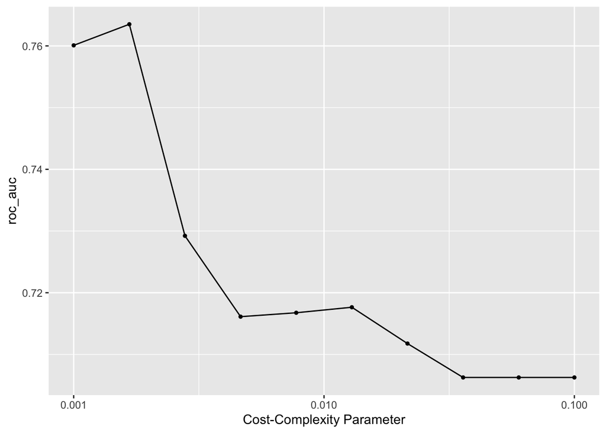

Figure 4.1: Model performance vs Cost-complexity Parameter

```r
# Set engine
tree_spec <- decision_tree() %>%
  set_engine("rpart")

# Set model
class_tree_spec <- tree_spec %>%
  set_mode("classification")

# Set workflow
class_tree_wkflow <- workflow() %>%
             add_recipe(my_recipe) %>%
             add_model(class_tree_spec %>%
                         set_args(cost_complexity = tune()) )

# Set cost complexity hyperparameter tuning
param_grid <- grid_regular(cost_complexity(range = c(-3, -1)), levels = 10)

# Fit the model to the folded data
#tune_res_tree <- tune_grid(
#  class_tree_wkflow,
#  resamples = data_fold,
#  grid = param_grid,
#  metrics = metric_set(roc_auc)
#)

# Save the results
#saveRDS(tune_res_tree, file = "tune_res_tree_saved.RData")

tune_res_tree_saved <- readRDS("tune_res_tree_saved.RData")

# Plot the result
autoplot(tune_res_tree_saved)
```

In Figure 4.1 one can observe that, for lower values of Cost-complexity parameter, the ROC-AUC is increasing in this parameter, and at a certain point, the ROC-AUC starts to be decreasing in this parameter. Now, we can proceed to select the best-performing model in the folded data, based on the ROC-AUC criterium.

```r
# Observe ROC-AUC of best model
roc_auc_pruned <- collect_metrics(tune_res_tree_saved) %>%
  arrange(desc(mean))

#roc_auc_pruned

# Select best pruned single tree
best_model_pruned <- select_best(tune_res_tree_saved, metric = "roc_auc")

class_tree_final <- finalize_workflow(class_tree_wkflow, best_model_pruned)

class_tree_final_fit <- fit(class_tree_final, data = data_train)
```

We observe that the best performing pruned single tree model has a Cost-complexity Parameter of 0.0017 and achieves an average ROC-AUC of 0.764 in the folded data. Figure 4.2 shows the decision tree using the best pruned single tree model.

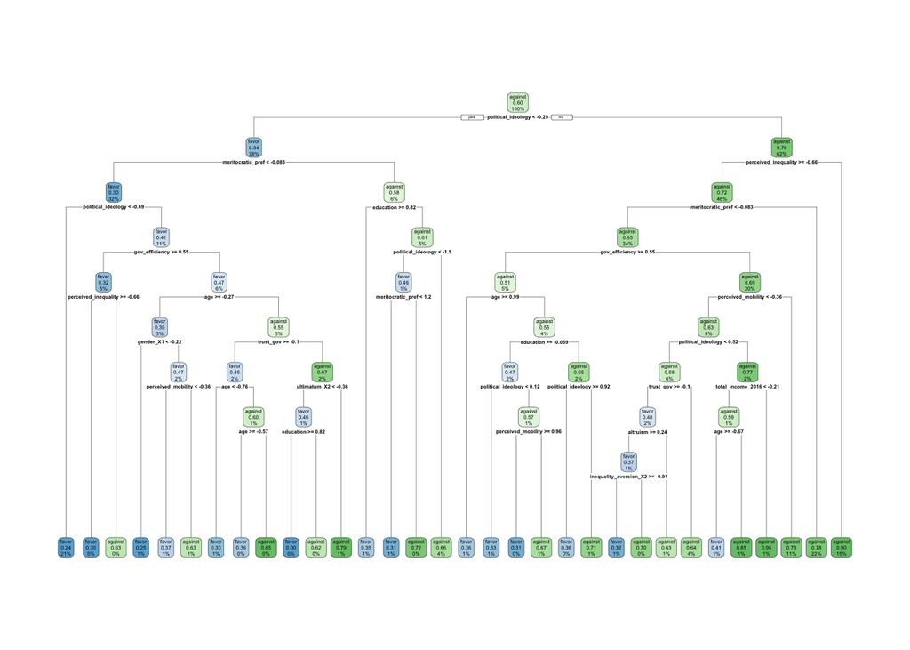

Figure 4.2: Best pruned single tree model

```r
# Visualize
class_tree_final_fit %>%
  extract_fit_engine() %>%
  rpart.plot()
```

## 4.2 Random forest model

Now, I perform a random forest model to predict redistribution preferences. To do that, I set a regular grid of 8 levels, where the number of predictors to be randomly sampled at each split when creating the models ranks from 1 to 17 (17 implies a bagging model), the number of trees ranks from 10 to 2000, and the minimum number of data points in a node that are required for the node to be split further ranks from 10 to 80.

```r
# Set Random forest model
rf_spec <- rand_forest(mtry = tune(), trees = tune(), min_n = tune() ) %>%
  set_engine("ranger", importance = "impurity") %>%
  set_mode("classification")

# Set workflow
rf_wkflow <- workflow() %>%
  add_recipe(my_recipe) %>%
  add_model(rf_spec)

# Create regular grids
model_grid <- grid_regular(mtry(range = c(1,17)), trees(range = c(10, 2000)),
                           min_n(range =c(10, 80)), levels = 8 )
```

Now, we can fit the random forest to the folded data.

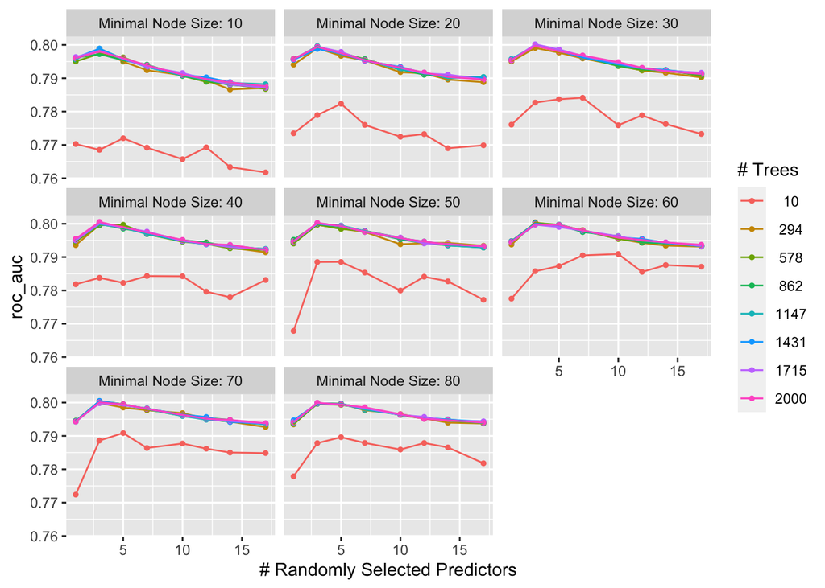

Figure 4.3: RF performance

```r
# Tune the model
#tune_res_rf <- tune_grid(
#  rf_wkflow,
#  resamples = data_fold,
#  grid = model_grid,
#  metrics = metric_set(roc_auc)
#)

#Save the results as an R object so we don't run it again every time we knit
#saveRDS(tune_res_rf, file="tune_res_rf_saved.RData")

tune_res_rf_saved <- readRDS("tune_res_rf_saved.RData")

autoplot(tune_res_rf_saved)
```

In Figure 4.3 we observe that, at first, ROC-AUC values are increasing in the number of predictors, and at a certain point, this relationship becomes negative. We also observe that models with 10 trees always have a relative bad performance, amd that models with a higher number of trees tend to do better. Regarding minimal node size, there are no big differences. It seems that for greater minimal node sizes, the relationship between ROC-AUC and number of selected predictors is flatter. We can now proceed to observe the best-performing models.

```r
# Take a look to the best-performing models
roc_auc_rf <- collect_metrics(tune_res_rf_saved) %>%
  arrange(desc(mean))

roc_auc_rf %>% head()
```

```
## # A tibble: 6 × 9
##    mtry trees min_n .metric .estimator  mean     n std_err .config
##   <int> <int> <int> <chr>   <chr>      <dbl> <int>   <dbl> <chr>
## 1     3  2000    40 roc_auc binary     0.801     5 0.00615 Preprocessor1_Model2…
## 2     3  1431    70 roc_auc binary     0.801     5 0.00629 Preprocessor1_Model4…
## 3     3   578    70 roc_auc binary     0.800     5 0.00648 Preprocessor1_Model4…
## 4     3   294    60 roc_auc binary     0.800     5 0.00587 Preprocessor1_Model3…
## 5     3  2000    50 roc_auc binary     0.800     5 0.00619 Preprocessor1_Model3…
## 6     3   578    60 roc_auc binary     0.800     5 0.00647 Preprocessor1_Model3…
```

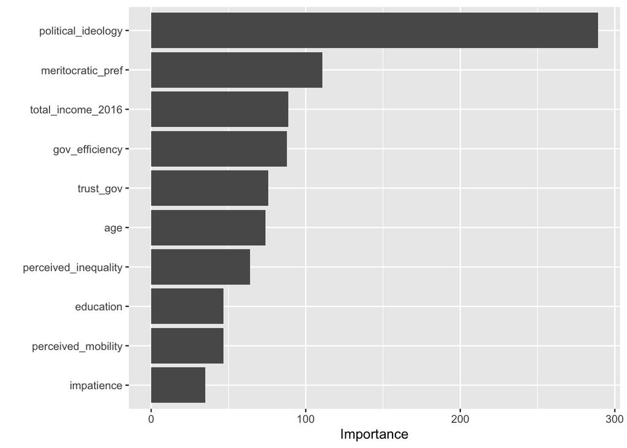

Figure 4.4: Variable importance of the best-performing RF model in the training set

```r
# Select the best model
best_model_rf <- select_best(tune_res_rf_saved, metric = "roc_auc")

# Select the final specification based on the best model
rf_final_spec <- rand_forest(mtry = best_model_rf$mtry,
                             trees = best_model_rf$trees,
                             min_n = best_model_rf$min_n ) %>%
  set_engine("ranger", importance = "impurity") %>%
  set_mode("classification")

# Specify the regression and training data: I do this instead of using the old recipe
# because it seems that the vip() function does not work with it. So I specify here
# the same specification I used before but without using a recipe.

# factors_vector is an auxiliar vector with predictors that are factors
factors_vector <- data %>%
  select(gender, i_capital, inequality_aversion, trust_game, ultimatum) %>%
  colnames()
# numeric variables auxiliar vector
numeric_vector <- data  %>%
  select(-pref_redistribution, -gender, -i_capital, -inequality_aversion, -trust_game, -ultimatum) %>%
  colnames()

data_train_b <- data_train %>%
  mutate(across(factors_vector, ~ as.numeric(.) )) %>% # factors to numeric
  mutate(gender = ifelse(gender==2,1,0)) %>% # create dummy
  mutate(i_capital = ifelse(i_capital==2,1,0)) %>% # create dummy
  mutate(inequality_aversion = ifelse(inequality_aversion==2,1,0)) %>% # create dummy
  mutate(trust_game = ifelse(trust_game==2,1,0))  %>% # create dummy
  mutate(ultimatum = ifelse(ultimatum==2,1,0)) # create dummy


# standarize numeric variables so they have mean = 0 and SD = 1
data_train_b <- data_train_b %>%
  mutate_at(numeric_vector, ~(scale(.) %>% as.vector))


rf_final_spec_fit <- fit(rf_final_spec, pref_redistribution ~
                           total_income_2016 + age + gender + education +
         risk_aversion + impatience + altruism + inequality_aversion + trust_game +
         ineq_tolerance + ultimatum + meritocratic_pref + perceived_mobility +
         perceived_inequality + trust_gov + gov_efficiency + political_ideology,
         data = data_train_b)

# Variable importance visualization
vip(rf_final_spec_fit)
```

## 4.3 Boosted trees

The last exercise of the paper consists of fitting a boosted tree model. To do that, I set a regular grid of 20 levels, and I let the trees range vary from 1 to 100 (after having checked that including greater number of trees only creates really low ROC-AUC values).

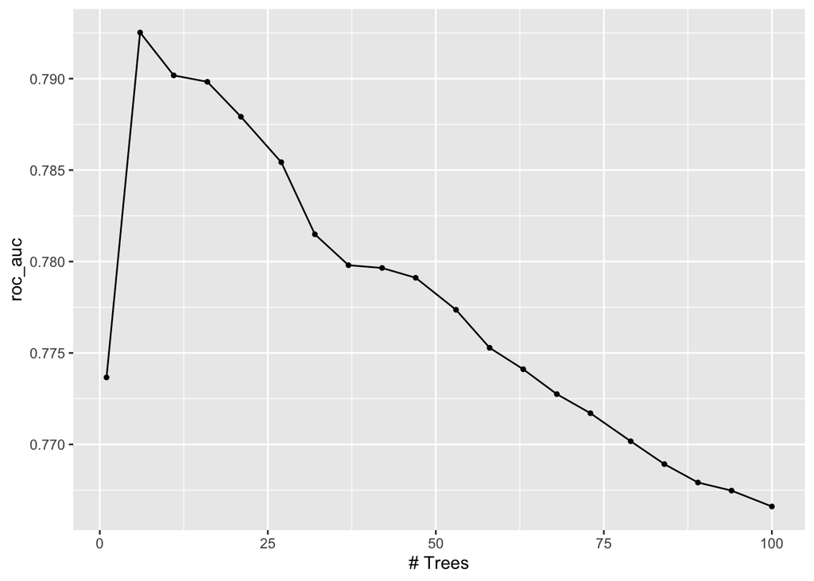

Figure 4.5: Boosted tree model

```r
# Boosted specification
boost_spec <- boost_tree(trees = tune()) %>%
  set_engine("xgboost") %>%
  set_mode("classification")

# Set up workflow
boost_wkflow <- workflow() %>%
  add_model(boost_spec) %>%
  add_recipe(my_recipe)

# Create regular grids
#boost_grid <- grid_regular(trees(range = c(10,2000)), levels = 10)
boost_grid <- grid_regular(trees(range = c(1,100)), levels = 20)

# Tuning the Boosted model
tune_res_boosted <- tune_grid(
  boost_wkflow,
  resamples = data_fold,
  grid = boost_grid,
  metrics = metric_set(roc_auc)
)

saveRDS(tune_res_boosted, file="tune_res_boosted_saved.RData")

tune_res_boosted_saved <- readRDS("tune_res_boosted_saved.RData")

autoplot(tune_res_boosted_saved)
```

Figure 4.5 shows that ROC_AUC is at first increasing in the number of trees, but this relationship quickly becomes negative for more than 10 trees. I can now proceed to select the best-performing boosted tree model in the folds. This model has 6 trees and achieves a ROC-AUC of 0.793.

```r
# Best-performing boosted tree model
roc_auc_boosted_rf <- collect_metrics(tune_res_boosted_saved) %>%
  arrange(desc(mean))

roc_auc_boosted_rf %>% head()
```

```
## # A tibble: 6 × 7
##   trees .metric .estimator  mean     n std_err .config
##   <int> <chr>   <chr>      <dbl> <int>   <dbl> <chr>
## 1     6 roc_auc binary     0.793     5 0.00424 Preprocessor1_Model02
## 2    11 roc_auc binary     0.790     5 0.00409 Preprocessor1_Model03
## 3    16 roc_auc binary     0.790     5 0.00523 Preprocessor1_Model04
## 4    21 roc_auc binary     0.788     5 0.00461 Preprocessor1_Model05
## 5    27 roc_auc binary     0.785     5 0.00416 Preprocessor1_Model06
## 6    32 roc_auc binary     0.781     5 0.00493 Preprocessor1_Model07
```

```r
# Select the best model
best_model_boosted <- select_best(tune_res_boosted_saved, metric = "roc_auc")
```

# 5 Assessment of the models and fit to the testing set

In this section, I compare the four main best models I used throughout the paper, based on the ROC-AUC criterium in the folded data: the regularized logistic regression, the single tree, the random forest and the boosted tree. Last, I fit the best-performing model to the testing data and assess its performance.

```r
# Compare regularized, single tree, rf, boosted tree

# Table comparing the roc_auc of the best performing models
model_name <- c("Regularized model", "Pruned single tree",
                "Random Forest","Boosted tree")

roc_auc_trees <- c(roc_auc_regularized$mean[1], roc_auc_pruned$mean[1], roc_auc_rf$mean[1],
                   roc_auc_boosted_rf$mean[1]) %>%
  as_tibble() %>%
  rename("ROC-AUC" = value) %>%
  mutate(Model = model_name) %>%
  mutate_if(is.numeric, format, digits = 3)

roc_auc_trees <- roc_auc_trees[, c("Model", "ROC-AUC")]

# Table
kbl(roc_auc_trees,
    caption = "<center> Assessment of the main models in the folds",
    booktabs = TRUE,
    escape = FALSE,
    align = "lc") %>%
  kable_classic(full_width = F)
```

Table 5.1: Assessment of the main models in the folds

| Model | ROC-AUC |
| --- | --- |
| Regularized model | 0.783 |
| Pruned single tree | 0.764 |
| Random Forest | 0.801 |
| Boosted tree | 0.793 |

Table 5.1 compares ROC-AUC levels for four models: the regularized logistic regression, the pruned single tree, the random forest, and the boosted tree. We observe that the random forest model achieves the highest ROC-AUC, so we conclude that this is the best-performing model of the paper in the folds.

Now, we can finally fit the best model to the whole training set, and assess its performance in predicting redistribution preferences in the testing set.

```r
# Finalize/update workflow with the best model
final_rf <- finalize_workflow(rf_wkflow, best_model_rf) # rf is the best model, and we had selected in this object the best-performing rf before

# Fit it to the training set
final_fit <- fit(final_rf, data = data_train)

# Predict in the testing set
predicted_test <- augment(final_fit, new_data = data_test) %>%
  select(pref_redistribution, starts_with(".pred"))

# Table with assessment
acc_rf <- predicted_test %>%
  accuracy(truth = pref_redistribution, estimate = .pred_class) # accuracy

acc_rf_table <-  acc_rf$.estimate[1] %>%
  as_tibble() %>%
  rename(Accuracy = value)

roc_auc_rf <- predicted_test %>%
  roc_auc(truth = pref_redistribution, estimate = .pred_favor) # ROC-AUC

roc_auc_rf_table <- roc_auc_rf$.estimate[1] %>%
  as_tibble() %>%
  rename("ROC-AUC" = value)

models_name <- c("Random Forest") %>%
  as_tibble() %>%
  rename(Model = value)

rf_table <- bind_cols(acc_rf_table, roc_auc_rf_table) %>%
            mutate_if(is.numeric, format, digits = 3)

#final_rows <- bind_rows(en_table, rf_table)

final_table <- bind_cols(models_name, rf_table)

kbl(final_table,
    caption = "<center> Assessment of the RF in the testing set",
    booktabs = TRUE,
    escape = FALSE,
    align = "lcc") %>%
  kable_classic(full_width = F)
```

Table 5.2: Assessment of the RF in the testing set

| Model | Accuracy | ROC-AUC |
| --- | --- | --- |
| Random Forest | 0.75 | 0.804 |

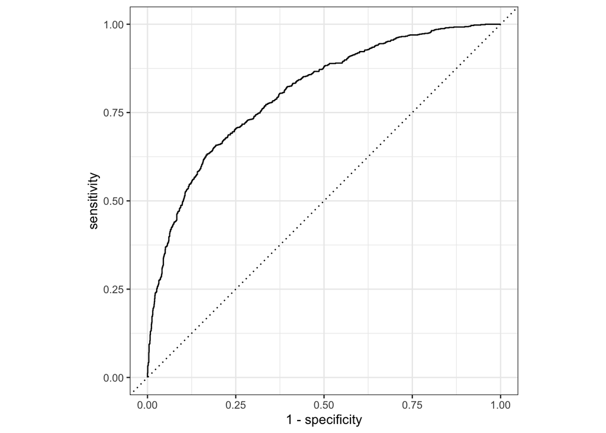

Figure 5.1: ROC-AUC curve of the best RF model in the testing set

```r
# Print the ROC curve
predicted_test %>%
  roc_curve(truth = pref_redistribution, estimate = .pred_favor) %>%
  autoplot()
```

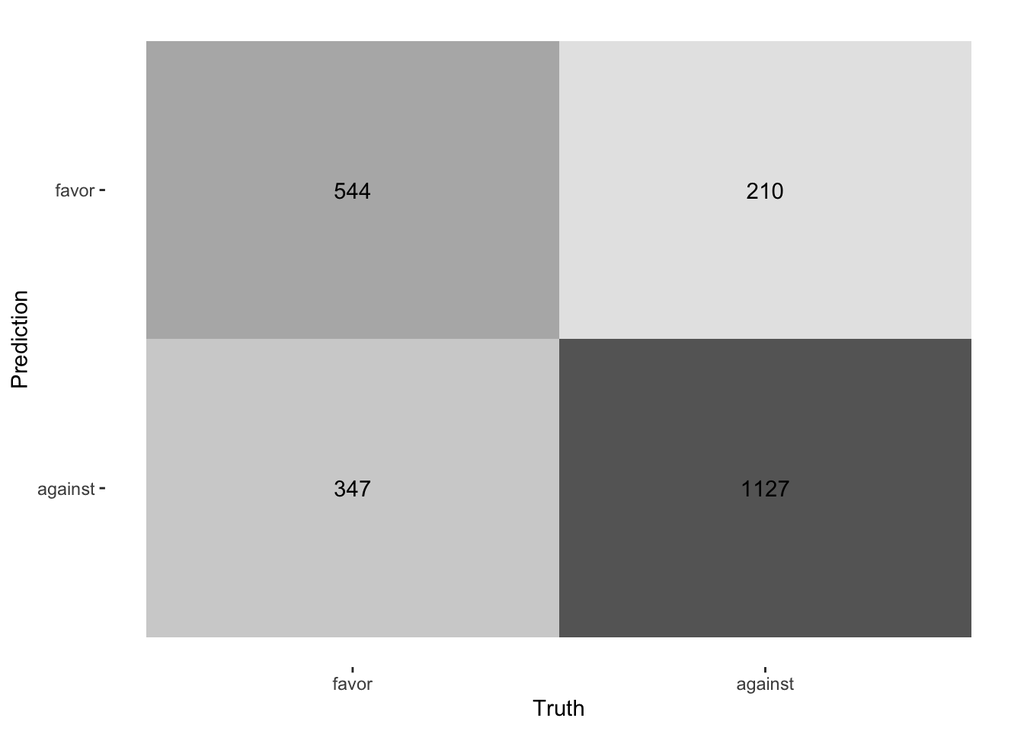

Figure 5.2: Confusion matrix of best RF in the testing set

```r
# Confusion matrix heatmap
predicted_test %>%
  conf_mat(truth = pref_redistribution, estimate = .pred_class) %>%
  autoplot(type = "heatmap")
```

# 6 Conclusion

In this paper, I exploited a combination of survey data and tax records in order to predict redistribution preferences of workers in Uruguay using Machine Learning approaches. The paper is split into two main analysis. The first analysis attempts to choose among a logistic regression, a linear discriminant analysis and a quadratic discriminant analysis. I analyzed the performance of these models based on the validation set approach, cross-validation and, finally, regularization. The second analysis, on the other hand, consists of predicting redistribution preferences using tree-based methods. Specifically, I performed a pruned single tree, a random forest, and a boosted tree model.

In the first part of the analysis, both LOGISTIC and LDA stand as the best-performing models in the folds. In the second part of the analysis, the random forest model stands as the best-performing model in the folds. Over all the models, the random forest is the best-performing model in the folded data.